# Plotting Natural Disasters

Edmund Julian Ofilada

February 26, 2018

# Synopsis

I just finished the awesome Building Data Visualization Course offeered by Coursera and I needed to find a project to practice the new skills I have learned. I picked for my topic natural disasters and I wanted to use data about the Philippines. In 2013, Within a span of three weeks, the Philippines was hit by two natural calamities that resulted in loss of lives and destruction of property. It also probably cost one man’s ambition of the presidency and catapulted another from obscurity to prominence.

```r
library(leaflet)
library(dplyr)
library(tidyr)
library(lubridate)
library(choroplethr)
library(ggplot2)
library(ggmap)
library(leaflet.extras)
library(htmlwidgets)
library(tigris)
```

## Downloading the data

The data we will be using comes from the [US Geological Survey](https://earthquake.usgs.gov/). They have a web service where you can input certain parameters and obtain the data you need. To use the service, click on this link https://earthquake.usgs.gov/earthquakes/search/

In keeping with Dr. Peng’s principle of making a presentation reproducible, the parameters I used for searching for the data are the following:

| Parameter | Value |
| --- | --- |
| Magnitude | 2.5+ |
| Start(UTC) | 2013-10-15 00:00:00 |
| End(UTC) | 2013-10-18 00:00:00 |

I also drew a rectangle on the Visayas area of the philippine map but I wasn’t able to log the longitude and latitude values created. I clicked on *Search* and downloaded the *.csv* file output of the search. In a future example, i will try using the USGS application programming interfaces (API).

```r
### make sure query.csv file is in your working directory

Oct_2015_Quake <- read.csv("query.csv",               ### read in query.csv in R and assign to R object Oct_2015_Quake
                           stringsAsFactors = FALSE)  ### read factors as characters
Oct_2015_Quake %>% select(time,                       ### select the variables time, latitude, longitude
                          latitude,                   ### mag, and place
                          longitude,
                          mag, place) %>%
        glimpse()                                     ### see data strcuture
```

```
## Observations: 83
## Variables: 5
## $ time      <chr> "2013-10-16T23:37:28.370Z", "2013-10-16T22:19:12.410...
## $ latitude  <dbl> 9.7020, 9.9295, 9.7679, 9.8926, 9.8188, 9.5926, 9.48...
## $ longitude <dbl> 123.7936, 123.9820, 123.5686, 124.0694, 123.8910, 12...
## $ mag       <dbl> 5.3, 4.9, 4.8, 4.8, 4.5, 4.9, 4.6, 5.2, 4.9, 4.6, 5....
## $ place     <chr> "6km SW of Bood, Philippines", "2km S of Panaytayon,...
```

Each row in the dataset contain a recorded earthquake and each variable describes the earthquake in terms of time, location, magnitude and other parameters. Since I am only interested in the three variables i just enumerated I will not bother mentioning the other variables included in the downloaded file.

## Tidying data

we see the time variable is read as a string of charactrers. We will transform it to a POSIXct object so we can use it in case we need to denote the time interval between recorded earthquakes. Furthermore, the data uses UTC or Coordinated Universal Time. UTC is the time standard for which the world regulates clocks and time. Philippine Standard Time (PST) is eight hours ahead of UTC. Since R does not recognize `PST` as a time zone, we will use `Asia/Taipei` instead.

We will also create another variable concatenating the magnitude of the earthquake and its location.

```r
Oct_2015_Quake <- Oct_2015_Quake %>%                         ### Take the R object we created Oct_2015_Quake
        mutate(date_time = ymd_hms(time,                     ### create new variable from time of class POSIXct
                                   tz = "Asia/Taipei")) %>%  ### Convert from UTC to Asia/Taipei time zone
        mutate(date = date(date_time),                       ### create date variable
               hr = hour(date_time),                         ### create hour variable
               mins = minute(date_time),                     ### create minutes variable
               secs = second(date_time)) %>%                 ### create seconds varaible
        select(date_time,                                    ### selct only the following variables: latitude.
               latitude,                                     ### longitude, mag, place, date, hr, mins, secs
               longitude,
               mag,
               place,
               date,
               hr,
               mins,
               secs)

Oct_2015_Quake$place <- gsub(", Philippines",                ### remove delete ", Philippines" in all rows of
                             "", Oct_2015_Quake$place)       ### variable Oct_2015$place

Oct_2015_Quake <- Oct_2015_Quake %>%                         ### take R object Oct_2015_Quake
        mutate(mag_loc = paste0(mag,                         ### create new variable mag_loc by combining
                                "Magnitude ",                ### the varaible mag, the strin Magnitude and
                                place))                      ### the variable place

max_mag <- Oct_2015_Quake %>%                                ### take R object Oct_2015_Quake
        dplyr::filter(mag == max(mag))                       ### extract row with highest magnitude earthquake

Oct_2015_Quake %>% select(date_time,                         ### select the following variables and show the
                          latitude,                          ### first six rows
                          longitude,
                          mag,
                          place,
                          mag_loc) %>%
        head()
```

```
##             date_time latitude longitude mag                place
## 1 2013-10-17 07:37:28   9.7020  123.7936 5.3       6km SW of Bood
## 2 2013-10-17 06:19:12   9.9295  123.9820 4.9  2km S of Panaytayon
## 3 2013-10-17 02:57:59   9.7679  123.5686 4.8 3km ENE of Dalaguete
## 4 2013-10-17 01:04:31   9.8926  124.0694 4.8   3km SW of Sagbayan
## 5 2013-10-16 23:35:33   9.8188  123.8910 4.5 4km NNW of Antequera
## 6 2013-10-16 23:32:45   9.5926  123.7010 4.9       2km W of Duljo
##                             mag_loc
## 1       5.3Magnitude 6km SW of Bood
## 2  4.9Magnitude 2km S of Panaytayon
## 3 4.8Magnitude 3km ENE of Dalaguete
## 4   4.8Magnitude 3km SW of Sagbayan
## 5 4.5Magnitude 4km NNW of Antequera
## 6       4.9Magnitude 2km W of Duljo
```

Now, we are ready to plot the data.

# Philippine Map

On October 15, 2013, tuesday 8:32 pm local time, the Philipines was rocked by a 7.1 M earthquake.

```r
bohol <- leaflet() %>%                    ### initialize leaflet to create map of Bohol
        setView(lng = 124.1167,           ### set arguments for longitude, latitude, and zoom
                lat =  9.8796,
                zoom = 4)
bohol %>%                                                    ### take map of Bohol
        addTiles() %>%                                       ### add tiles
        addProviderTiles("Thunderforest.TransportDark") %>%  ### specify type of map
        addPulseMarkers(                                     ### add pulsing marker and specif
    lng = max_mag$longitude,                                 ### longitude
    lat = max_mag$latitude,                                  ### and latitude of pulsing marker
    label='7.1 mag',                                         ### specify label
    labelOptions = labelOptions(noHide = TRUE,               ### specify labe options
                                textsize = "15px"),
    icon = makePulseIcon(heartbeat = 0.5))                   ### specify frequency of pulsing
```

[interactive chart not shown]

## Visayas Map

The earthquake occurred in a group of islands called Visayas in the Philippines. The epicenter was located in the island of Bohol 4 Km SE of the town of Sagbayan.

```r
bohol2 <- leaflet() %>%
        setView(lng = 124.1167,
                lat =  9.8796,
                zoom = 6)
bohol2 %>%
        addTiles() %>%
        addProviderTiles("Esri.NatGeoWorldMap") %>%
        addPopups(lng = max_mag$longitude,
                  lat = max_mag$latitude,
                  popup = "4km SE of Sagbayan, Bohol",
                  options = popupOptions(closeButton = FALSE))
```

[interactive chart not shown]

## Bohol map

After the initial tremor on tuesday, 82 aftershocks that are greater than 2.5 M have been recorded as of thursday, Oct 17.

```r
icon.pop <- pulseIcons(color = ifelse(Oct_2015_Quake$mag > 7,
                                      'red', ifelse(Oct_2015_Quake$mag < 5,
                                      'palevioletred', 'violetred')),
                       heartbeat = ifelse(Oct_2015_Quake$mag > 7,
                                          0.4, ifelse(Oct_2015_Quake$mag < 5,
                                      1, 0.8)),
                       iconSize = ifelse(Oct_2015_Quake$mag > 7,
                                          12, ifelse(Oct_2015_Quake$mag < 5,
                                      4, 8)))
bohol3 <- leaflet() %>%
        setView(lng = 124.1167,
                lat =  9.8796,
                zoom = 9)

bohol3 %>%
        addTiles() %>%
        addProviderTiles("OpenStreetMap.Mapnik") %>%
        addPulseMarkers(
    lng = Oct_2015_Quake$longitude, lat = Oct_2015_Quake$latitude,
    label= Oct_2015_Quake$place,
    icon = icon.pop)
```

[interactive chart not shown]

# Casualties

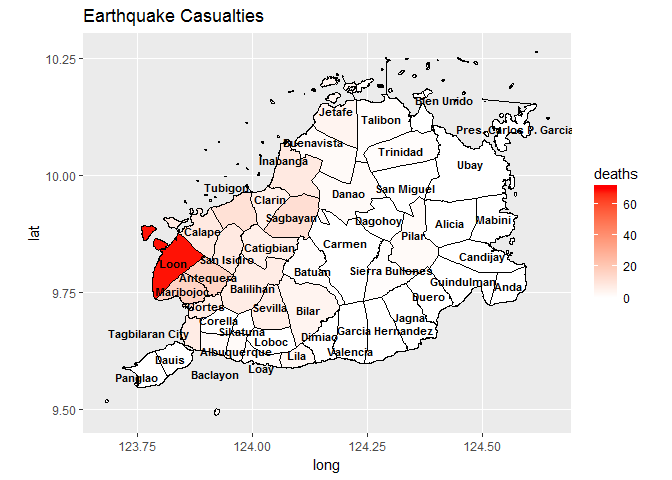

```r
plot_df2 <- read.csv("casualties.csv", stringsAsFactors = FALSE)
cnames <- read.csv("bohol_town_names.csv", stringsAsFactors = FALSE)
ggplot() +
  geom_polygon(data = plot_df2,
               aes(x = long,
                   y = lat,
                   group = group,
                   fill = casualties),
               color = "black",
               size = 0.25) +
  coord_map()+
  scale_fill_gradient(name="deaths",
                      limits=c(0,70),
                      low="white",
                      high="red") +
  labs(title="Earthquake Casualties") +
  geom_text(data=cnames,
            aes(long,
                lat,
                label = NAME_2),
            size=3,
            fontface="bold")
```

By November 4, 2013, two weeks after the 7.1 M earthquake, The [National Disaster Risk Reduction and Management Council](http://www.ndrrmc.gov.ph/) reported a total of 227 deaths in the provinces of Bohol (214), Cebu (12), and Siquijor (1).

# Injuries

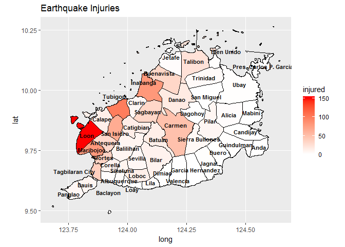

```r
plot_df3 <- read.csv("injured.csv", stringsAsFactors = FALSE)
ggplot() +
  geom_polygon(data = plot_df3,
               aes(x = long,
                   y = lat,
                   group = group,
                   fill = injured),
               color = "black",
               size = 0.25) +
  coord_map()+
  scale_fill_gradient(name="injured",
                      limits=c(0,151),
                      low="white",
                      high="red") +
  labs(title="Earthquake Injuries") +
  geom_text(data=cnames,
            aes(long,
                lat,
                label = NAME_2),
            size=3,
            fontface="bold")
```

**A total of 976 individuals were injured, 967 were from Bohol**.

# Totally Damaged Houses in Bohol

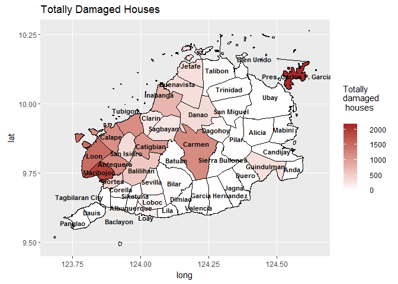

```r
plot_df4 <- read.csv("totally_damaged_houses.csv", stringsAsFactors = FALSE)
ggplot() +
  geom_polygon(data = plot_df4,
               aes(x = long,
                   y = lat,
                   group = group,
                   fill = tot_damaged),
               color = "black",
               size = 0.25) +
  coord_map()+
  scale_fill_gradient(name="Totally \ndamaged \n houses",
                      limits=c(0,2130),
                      low="white",
                      high="brown") +
  labs(title="Totally Damaged Houses") +
  geom_text(data=cnames,
            aes(long,
                lat,
                label = NAME_2),
            size=3,
            fontface="bold")
```

** 78,229 houses were damaged (15,933 totally / 62,296 partially) in Bohol, Cebu, Negros Occidental, Iloilo, Siquijor and Guimaras**.

- 41 bridges were damaged in Bohol, Cebu, and Negors Occidental.
- A total of PHP 2,257,337,182.90 worth of Public infrastructure were damaged.

```r
 hist(Oct_2015_Quake$mag)
```

[output not shown]

# Super Typhoon Haiyan

Barely three weeks after the earthquake, super typhoon Haiyan or better known locally as typhoon Yolanda made land fall on the town of Guiuan, Eastern Samar.

## Reading in Typhoon Data

Data for typhoon haiyan came from the National Oceanic and Atmospheric Administration (NOAA). The International Best Track Archive for Climate Stewardship (IBTrACS) is a global set of historical tropical cyclones. The data is derived from contributions from various world wide agencies tasked to monitor climate and weather. Description of the data and instructions for downloading the data are available at https://www.ncdc.noaa.gov/ibtracs/index.php?name=ibtracs-data-access

The storm data for the year 2013 was downloaded from this ftp site. The variable names contain prefixes to denote the institute/agency that contributed the data. For our purposes we will use the data from the Joint typhoon Warning System (JWTC).

```r
ibtracks2013 <- read.csv("Year.2013.ibtracs_all.v03r10.csv", ### take the downloaded file from NOAA and read
                         skip = 1,                           ### content but skip firsst row
                         stringsAsFactors = FALSE,           ### read factors as strings or characters
                         na.strings = "-999.0")              ### specify code for missing values

var_names <- c("Name", "ISO_time")                           ### create var names containing Name and ISO_time

haiyan <- ibtracks2013 %>%                                   ### take the r object ibtracks2013 we created
        filter(Name == "HAIYAN") %>%                         ### filter typhoon haiyan
        select(var_names, starts_with("jtwc"))               ### select varaibles Name, ISO_time, and all variables beginning with the string jtwc

jtwc <- haiyan %>%                                           ### take r object haiyan and
        select(starts_with("jtwc"))                          ### select only variables beginning with jtwc

non_jtwc <- haiyan %>%                                       ### take r object haiyan and
        select(1:4)                                          ### select only variables Name, ISO_time, jtwc_sh_lat

non_jtwc$ISO_time <- ymd_hms(non_jtwc$ISO_time)            ### convert ISO_time to POSIXct object

jtwc_df <- as.data.frame(rbind(sapply(jtwc, as.numeric)))    ### convert all variables in jtwc_df to numeric and row bind

var_empty <- sapply(jtwc_df, function(x) sum(is.na(x)))      ### check which variables are empty/ all missing data

index <- var_empty == 38                                     ### create index which variables contain only NAs

plot_df <-cbind(non_jtwc, jtwc_df[, !index])                 ### use index to remove varaibles that contain only NAs

plot_df <- plot_df %>%                                       ### remove last row
        select(-starts_with("jtwc_sh")) %>%
        slice(1:37)

plot_df                                                      ### show first 10 rows of data
```

```
## # A tibble: 37 x 22
##    Name   ISO_time            jtwc_wp_lat jtwc_wp_lon jtwc_wp_wind
##    <chr>  <dttm>                    <dbl>       <dbl>        <dbl>
##  1 HAIYAN 2013-11-02 06:00:00         6.6        162.           15
##  2 HAIYAN 2013-11-02 12:00:00         6.2        160.           15
##  3 HAIYAN 2013-11-02 18:00:00         6.1        159.           15
##  4 HAIYAN 2013-11-03 00:00:00         6.2        157.           20
##  5 HAIYAN 2013-11-03 06:00:00         6.3        156.           25
##  6 HAIYAN 2013-11-03 12:00:00         6.6        154.           30
##  7 HAIYAN 2013-11-03 18:00:00         6.3        153.           30
##  8 HAIYAN 2013-11-04 00:00:00         6.1        152.           35
##  9 HAIYAN 2013-11-04 06:00:00         6.1        150.           40
## 10 HAIYAN 2013-11-04 12:00:00         6.3        149.           45
## # ... with 27 more rows, and 17 more variables: jtwc_wp_pres <dbl>,
## #   jtwc_.._rmw <dbl>, jtwc_.._poci <dbl>, jtwc_.._roci <dbl>,
## #   jtwc_.._eye <dbl>, jtwc_.._wrad34_rad1 <dbl>,
## #   jtwc_.._wrad34_rad2 <dbl>, jtwc_.._wrad34_rad3 <dbl>,
## #   jtwc_.._wrad34_rad4 <dbl>, jtwc_.._wrad50_rad1 <dbl>,
## #   jtwc_.._wrad50_rad2 <dbl>, jtwc_.._wrad50_rad3 <dbl>,
## #   jtwc_.._wrad50_rad4 <dbl>, jtwc_.._wrad64_rad1 <dbl>,
## #   jtwc_.._wrad64_rad2 <dbl>, jtwc_.._wrad64_rad3 <dbl>,
## #   jtwc_.._wrad64_rad4 <dbl>
```

## Description of the Variables

Below is a brief description of the data from the Joint Typhoon Warning Center (JTWC).

| Argument | Description |
| --- | --- |
| Name | Storm name |
| ISO_time | Date and time in ISO format: YYYY-MM-DD HH:MM:SS |
| jtwc_wp_lat | Latitude (Degrees North) |
| jtwc_wp_lon | Longitude (degrees East) |
| jtwc_wp_wind | Sustained wind speed in knots: 0 through 300 |
| jtwc_wp_pres | Minimum sea level pressure, 1 through 1100 MB. |
| jtwc_.._rmw | radius of maximum wind |
| jtwc_.._poci | pressure of the outer most closed isobar |
| jtwc_.._roci | radius of the outer most closed isobar |
| jtwc_.._eye | eye diameter, 0 through 999 nm. |
| jtwc_.._wrad34_rad1 | northeast radii of the storm’s 34 knot winds in nautical miles |
| jtwc_.._wrad34_rad2 | southeast radii of the storm’s 34 knot winds in nautical miles |
| jtwc_.._wrad34_rad3 | southwest radii of the storm’s 34 knot winds in nautical miles |
| jtwc_.._wrad34_rad4 | northwest radii of the storm’s 34 knot winds in nautical miles |
| jtwc_.._wrad50_rad1 | northeast radii of the storm’s 50 knot winds in nautical miles |
| jtwc_.._wrad50_rad2 | southeast radii of the storm’s 50 knot winds in nautical miles |
| jtwc_.._wrad50_rad3 | southwest radii of the storm’s 50 knot winds in nautical miles |
| jtwc_.._wrad50_rad4 | northwest radii of the storm’s 50 knot winds in nautical miles |
| jtwc_.._wrad64_rad1 | northeast radii of the storm’s 64 knot winds in nautical miles |
| jtwc_.._wrad64_rad2 | southeast radii of the storm’s 64 knot winds in nautical miles |
| jtwc_.._wrad64_rad3 | southwest radii of the storm’s 64 knot winds in nautical miles |
| jtwc_.._wrad64_rad4 | northwest radii of the storm’s 64 knot winds in nautical miles |

## Tidying the data

We will need to create shorter and more decriptive names to our variables and organize them in a way that will make plotting easier.

```r
names(plot_df) <- c("name", "date_time", "latitude",       ### change variable names to more meaningful names
                    "longitude", "wind", "pressure",
                    "max_wind_rad", "poci", "roci",
                    "eye_diameter", "34_ne", "34_se",
                    "34_sw", "34_nw", "50_ne",
                    "50_se", "50_sw", "50_nw",
                    "64_ne", "64_se", "64_sw", "64_nw")

plot_df <- plot_df %>% select(name,                       ### select variables name, date_time, latitude, longitude
                              date_time,                  ### and variables 11 to 22
                              latitude,
                              longitude,
                              11:22) %>%
        gather(key = wind_spd_dir,                        ### gather all varaible to column wind_spd_dir except variables
               value = value,                             ### name, date_time, latitude, longitude
               -name,
               -date_time,
               -latitude,
               -longitude,
               na.rm = TRUE) %>%                          ### don't include NAs or missing values
        separate(col = wind_spd_dir,                      ### separate wind_spd_dir to wind_spd and dir
                 c("wind_spd", "dir")) %>%
        spread(dir, value) %>%
        arrange(date_time,                                ### arrange rows according to date_time, latitude,
                latitude,                                 ### and longitude
                longitude)

plot_df$wind_spd <- as.factor(plot_df$wind_spd)           ### convert variable wind_spd to factor

nov4AM6 <-plot_df %>% slice(25:27)                        ### create dataframe with only row 25:27
nov5AM6 <-plot_df %>% slice(37:39)
nov6AM6 <-plot_df %>% slice(49:51)
nov7AM6 <-plot_df %>% slice(61:63)
nov8AM0 <-plot_df %>% slice(79:81)
nov8bohol <-plot_df %>% slice(70:72)
nov9AM18 <-plot_df %>% slice(91:93)
nov10AM12 <-plot_df %>% slice(100:102)
nov11AM6 <-plot_df %>% slice(109:111)

nov8bohol
```

```
## # A tibble: 3 x 9
##   name   date_time           latitude longitude wind_spd    ne    nw    se
##   <chr>  <dttm>                 <dbl>     <dbl> <fct>    <dbl> <dbl> <dbl>
## 1 HAIYAN 2013-11-08 00:00:00       11      125. 34         130   130   115
## 2 HAIYAN 2013-11-08 00:00:00       11      125. 50          65    70    60
## 3 HAIYAN 2013-11-08 00:00:00       11      125. 64          50    50    45
## # ... with 1 more variable: sw <dbl>
```

```r
### R code to create geom_hurricane

GeomHurricane <- ggplot2::ggproto(
        `_class` = "GeomHurricane",          ### name of new geom
        `_inherit` = Geom,                   ### class of R object
        required_aes = c("x",                ### argument for lingitude
                         "y",                ### argument for latitude
                         "r_ne",             ### argument for NE wind radius
                         "r_se",             ### argument for SE wind radius
                         "r_sw",             ### argument for SW wind radius
                         "r_nw"),            ### argument for NW wind radius
        default_aes = aes(colour = "NA",     ### default value for colour argument
                          fill = "NA",       ### default value for fill argument
                          linetype = 1,      ### default value for linetype argument
                          alpha = 0.8,       ### default value for alpha argument
                          scale_radii = 1),  ### default value for scale_radii argument
        draw_key = draw_key_polygon,         ### setting draw_key_polygon to draw legend
        draw_group = function(data,                 ### selecting draw_group over draw_panel
                              panel_scales,         ### elements are grouped according to wind_speed
                              coord){              ### data describing coordinates
                center_pt <- c(data[1, ]$x,         ### coordinates for longitude
                               data[1, ]$y)         ### coordinates for latitude
                color <- data[1, ]$colour           ### selecting colour from first row
                fill <- data[1, ]$fill              ### selecting fill from first row
                alpha <- data[1, ]$alpha            ### selecting alpha from first row
                scale_radii = data[1, ]$scale_radii ### selecting scale_radii from first row
                ne_qtr_circ <- geosphere::destPoint(p = center_pt, ### setting center of arc
                                                    b = 0:90,      ### setting points for arc
                                                    d = data[1, ]$r_ne * 1852 * scale_radii) ### setting radius
                ### converted nautical miles to meters by multiplying aby 1852 and to map scale by scale_radii

                ne_df <- data.frame(x = c(ne_qtr_circ[, "lon"],
                                          center_pt[1]),
                                    y = c(ne_qtr_circ[, "lat"],
                                          center_pt[2])
                )
                se_qtr_circ <- geosphere::destPoint(p = center_pt, ### setting center of arc
                                                    b = 90:180,      ### setting points for arc
                                                    d = data[1, ]$r_se * 1852 * scale_radii) ### setting radius
                ### converted nautical miles to meters by multiplying aby 1852 and to map scale by scale_radii

                se_df <- data.frame(x = c(se_qtr_circ[, "lon"],
                                          center_pt[1]),
                                    y = c(se_qtr_circ[, "lat"],
                                          center_pt[2])
                )

                nw_qtr_circ <- geosphere::destPoint(p = center_pt, ### setting center of arc
                                                    b = 270:360,      ### setting points for arc
                                                    d = data[1, ]$r_nw * 1852 * scale_radii) ### setting radius
                ### converted nautical miles to meters by multiplying aby 1852 and to map scale by scale_radii

                nw_df <- data.frame(x = c(nw_qtr_circ[, "lon"],
                                          center_pt[1]),
                                    y = c(nw_qtr_circ[, "lat"],
                                          center_pt[2])
                )

                sw_qtr_circ <- geosphere::destPoint(p = center_pt, ### setting center of arc
                                                    b = 180:270,      ### setting points for arc
                                                    d = data[1, ]$r_sw * 1852 * scale_radii) ### setting radius
                ### converted nautical miles to meters by multiplying aby 1852 and to map scale by scale_radii

                sw_df <- data.frame(x = c(sw_qtr_circ[, "lon"],
                                          center_pt[1]),
                                    y = c(sw_qtr_circ[, "lat"],
                                          center_pt[2])
                )

                all_df <- rbind(ne_df, se_df, nw_df, sw_df)
                coords <- coord$transform(all_df,
                                          panel_scales)

                grid::polygonGrob(x = coords$x,
                                  y = coords$y,
                                  gp = grid::gpar(col = color,
                                                  fill = fill,
                                                  alpha =alpha))
        }

)

geom_hurricane <- function(mapping = NULL,
                           data = NULL,
                           stat = "identity",
                           position = "identity",
                           na.rm = FALSE,
                           show.legend = NA,
                           inherit.aes = TRUE,
                           ...) {
        ggplot2::layer(
                geom = GeomHurricane,
                mapping = mapping,
                data = data,
                stat = stat,
                position = position,
                show.legend = show.legend,
                inherit.aes = inherit.aes,
                params = list(na.rm = na.rm,
                              ...)
        )
}
```

# Plotting Hurricane Haiyan

Typhoon Haiyan was spawned east-southeast of Pohnpei Island of the Federated States of Micronesia.

- **November 4**, the Japan Meteorological Agency classified the weather event as a tropical storm after its winds reached a measured speed of 40 miles (64 km) per hour and assigned the name Haiyan,
- **November 5**, the storm reached typhoon strength With winds increasing to 75 miles (120 km) per hour.
- **November 6**, Haiyan intensified into a super typhoon With winds increasing to 178 miles (287 km) per hour.
- **Novemeber 7**, 5 hrs before landfall, Haiyan’s intensity peaked with 1-minute sustained winds of 195. The wind speed at landfall of 195 mph is the strongest tropical cyclone winds to impact land, surpassing Hurricane Camille, which hit the U.S. state of Mississippi in 1969 and had winds of 190 mph.
- **November 8**, 4:40 am local time, Super Typhoon Haiyan made landfall at Guiuan, eastern Samar.

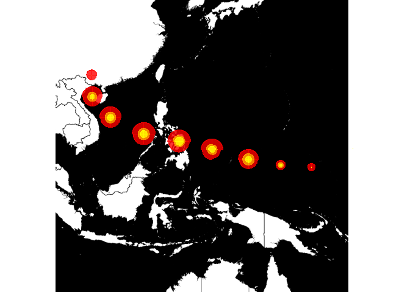

```r
map_plot <- get_map(c(lon = 129,                       ###get map from google
                      lat = 10.2),                     ### specify arguments for longitude, latitude, zoom
                    zoom = 4,                          ### and maptype
                    maptype = "toner-background")

chron <- map_plot %>%                                  ### plot hurricane using geom_hurricane function
  ggmap(extent = "device") +
  geom_hurricane(data = nov4AM6,
                 aes(x = longitude,
                     y = latitude,
                     r_ne = ne,
                     r_se = se,
                     r_nw = nw,
                     r_sw = sw,
                     color = wind_spd,
                     fill = wind_spd),
                 scale_radii = 1) +
  geom_hurricane(data = nov5AM6,
                 aes(x = longitude,
                     y = latitude,
                     r_ne = ne,
                     r_se = se,
                     r_nw = nw,
                     r_sw = sw,
                     color = wind_spd,
                     fill = wind_spd),
                 scale_radii = 1) +
  geom_hurricane(data = nov6AM6,
                 aes(x = longitude,
                     y = latitude,
                     r_ne = ne,
                     r_se = se,
                     r_nw = nw,
                     r_sw = sw,
                     color = wind_spd,
                     fill = wind_spd),
                 scale_radii = 1) +
  geom_hurricane(data = nov7AM6,
                 aes(x = longitude,
                     y = latitude,
                     r_ne = ne,
                     r_se = se,
                     r_nw = nw,
                     r_sw = sw,
                     color = wind_spd,
                     fill = wind_spd),
                 scale_radii = 1) +
  geom_hurricane(data = nov8AM0,
                 aes(x = longitude,
                     y = latitude,
                     r_ne = ne,
                     r_se = se,
                     r_nw = nw,
                     r_sw = sw,
                     color = wind_spd,
                     fill = wind_spd),
                 scale_radii = 1) +
  geom_hurricane(data = nov9AM18,
                 aes(x = longitude,
                     y = latitude,
                     r_ne = ne,
                     r_se = se,
                     r_nw = nw,
                     r_sw = sw,
                     color = wind_spd,
                     fill = wind_spd),
                 scale_radii = 1) +
  geom_hurricane(data = nov10AM12,
                 aes(x = longitude,
                     y = latitude,
                     r_ne = ne,
                     r_se = se,
                     r_nw = nw,
                     r_sw = sw,
                     color = wind_spd,
                     fill = wind_spd),
                 scale_radii = 1) +
  geom_hurricane(data = nov11AM6,
                 aes(x = longitude,
                     y = latitude,
                     r_ne = ne,
                     r_se = se,
                     r_nw = nw,
                     r_sw = sw,
                     color = wind_spd,
                     fill = wind_spd),
                 scale_radii = 1) +
  geom_hurricane(data = nov8bohol,
                 aes(x = longitude,
                     y = latitude,
                     r_ne = ne,
                     r_se = se,
                     r_nw = nw,
                     r_sw = sw,
                     color = wind_spd,
                     fill = wind_spd),
                 scale_radii = 1) +
  scale_color_manual(name = "Wind speed (kts)",
                     values = c("red",
                                "orange",
                                "yellow")) +
  scale_fill_manual(name = "Wind speed (kts)",
                    values = c("red",
                               "orange",
                               "yellow")) +
  guides(col=guide_legend(title="Wind\nspeed\n(kts)"))

chron
```

- **Novemeber 9**, 3:30 pm local time, Super typhoon Haiyan was outside the Philippine Area of Responsibility.
- **November 10**, Haiyan struck land once again near Ha Long Bay in Vietnam’s Quang Ninh province at 5:00 am on November 10. By then the storm’s winds had weakened to less than 85 miles (138 km) per hour at landfall.
- **November 11**, It turned northward into China’s Zhuang Autonomous Region of Guangxi by November 11, where it further weakened and was downgraded to a tropical storm.

## Hurricane Haiyan over Bohol, Samar, and Leyte

Barely 3 weeks after the 7.1 M earthquake struck at Sagabayan, Bohol, Super Typhoon Haiyan made landfall at the town of Guiuan, Eastern Samar. The red, orange, and yellow area indicating wind speed of 34, 50, and 64 knots winds (63, 93, 118 km/hr).

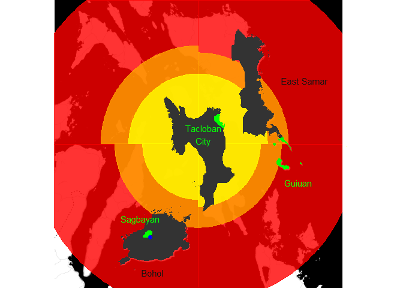

```r
leyte_casualties <- read.csv("leyte_casualties.csv")
phil_map <- readRDS("PHL_adm2.rds")                           ###read shape files for Philippine Map
bohol_map <- phil_map[phil_map$NAME_1 == "Bohol", ]           ### filter only map for Bohol
bohol_mapdf <- fortify(bohol_map)                             ### use fortify function so you can use map in ggplot

sagbayan_map <- phil_map[phil_map$NAME_2 == "Sagbayan", ]     ### filter map only for sagbayan
sagbayan_mapdf <- fortify(sagbayan_map)                       ### use fortify function so you can use map in ggplot

Esamar_map <- phil_map[phil_map$NAME_1 == "Eastern Samar", ]
Esamar_mapdf <- fortify(Esamar_map)


guiuan_map <- phil_map[phil_map$NAME_2 == "Guiuan", ]
guiuan_mapdf <- fortify(guiuan_map)

dist <- mapdist("Sagbayan, Bohol", "Guiuan, Samar")

guiuan <- geocode("Guiuan, Samar")

towns <- data.frame(list(places = c("Guiuan",     ### create dataframe for labels for Guiuan and sagbayan
                                    "Sagbayan",
                                    "Tacloban\nCity"),
                         lon = c(125.9245,
                                 123.9975,
                                 124.7644),
                         lat = c(10.53525,
                                 10.09920,
                                 11.11317)))
prov <- data.frame(list(places = c("East Samar",  ### create dataframe for labels for East Samar and Bohol
                                   "Bohol"),
                        lon = c(125.9950,
                                124.1435),
                        lat = c(11.758273,
                                9.449991)))


leyte_map <- phil_map[phil_map$NAME_1 == "Leyte", ]           ### filter only map for Leyte
leyte_mapdf <- fortify(leyte_map, region = "ID_1")                             ### use fortify function so you can use map in ggplot

tacloban_map <- phil_map[phil_map$NAME_2 == "Tacloban City", ]     ### filter map only for Tacloban
tacloban_mapdf <- fortify(tacloban_map, region = "ID_2")                       ### use fortify function so you can use map in ggplot


leyte_towns_merged <- geo_join(leyte_map, leyte_casualties, "NAME_2", "town")


map_plot <- get_map(c(lon = 124.7,                  ### get map from ggogle map
                      lat = 11),                    ### specify arguments for longitude, latitude,zoom
                    zoom = 8,                       ### and maptype
                    maptype = "toner-background")

covered <- map_plot %>%                             ### use map we created earlier
  ggmap(extent = "device") +                        ### specify border of map
  geom_hurricane(data = nov8bohol,                  ### specify dataframe to use
                 aes(x = longitude,                 ### specify argument for longitude
                     y = latitude,                  ### specify argument for latitude
                     r_ne = ne,                     ### specify northeast radius
                     r_se = se,                     ### specify southeat radius
                     r_nw = nw,                     ### specify northwest radius
                     r_sw = sw,                     ### specify southwest radius
                     color = wind_spd,              ### specify argument for color
                     fill = wind_spd),              ### specify argument for wind_spd
                 scale_radii = 1) +                 ### specify what percent of radii will be shown
  scale_color_manual(name = "Wind speed (kts)",     ### create legend
                     values = c("red",
                                "orange",
                                "yellow")) +
  scale_fill_manual(name = "Wind speed (kts)",
                    values = c("red",
                               "orange",
                               "yellow")) +
        geom_polygon(data = bohol_mapdf,            ### create map of bohol
                     aes(x = long,
                         y = lat,
                         group = group)) +
        geom_polygon(data = sagbayan_mapdf,         ### create map of sagbayan and color it green
                     aes(x =long,
                         y = lat,
                         group = group),
                     fill = "green") +
        geom_point(data = max_mag,                  ### mark epicenter of 7.1 M earthquake
                   aes(x= longitude,
                       y = latitude),
                   color = "blue", size = 2) +
        geom_polygon(data = Esamar_mapdf,           ### create map of eastern samar
                     aes(x= long,
                         y = lat,
                         group = group)) +
        geom_polygon(data = guiuan_mapdf,           ### create map of guiuan and color it green
                     aes(x = long,
                         y = lat,
                         group = group),
                     fill = "green") +
        geom_polygon(data = leyte_mapdf,           ### create map of eastern samar
                     aes(x= long,
                         y = lat,
                         group = group)) +
        geom_polygon(data = tacloban_mapdf,           ### create map of guiuan and color it green
                     aes(x = long,
                         y = lat,
                         group = group),
                     fill = "green") +
        geom_text(data = prov,                      ### create labels for Eastern samar and Bohol
                  aes(x = lon,
                      y = lat,
                      label = places),
                  color = "gray7") +
        geom_text(data = towns,                     ### create labels for guiuan and sagbayan
                  aes(x = lon,
                      y = lat,
                      label = places),
                  color = "green") +
        guides(col=guide_legend(title="Wind\nspeed\n(kts)"))

covered
```

# Satellite image

Satellite image showing Haiyan as it made landfall.

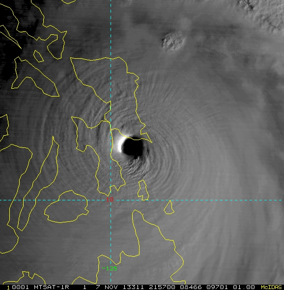

By November 9, 2013, The [National Disaster Risk Reduction and Management Council](http://www.ndrrmc.gov.ph/) reported:

- a total of 6300 reported deaths, 28,688 injured and 1,062 are still missing.

The hardest hit was the island of Leyte. Tacloban city suffered the greatest number of casualties shown on the map as dark green. To see the number of death and injured in each town in Leyte, click on the areas between the administrative boundaries. Clicking on the + or - sign allows for zooming in or out.

# Map of fatalities and injured

```r
# Creating a color palette based on the number range in the total column

pal <- colorNumeric("Greens", domain = leyte_towns_merged$dead)
# Setting up the pop up text
popup_sb <- paste0(as.character(leyte_towns_merged$town), ": ", as.character(leyte_towns_merged$dead), " Casualties: ", as.character(leyte_towns_merged$unidentified), " unidentified")

# Mapping it with the new tiles CartoDB.Positron
leaflet() %>%
  addProviderTiles("CartoDB.Positron") %>%
  setView(124.7001, 11.08302, zoom = 9) %>%
  addPolygons(data = leyte_towns_merged ,
              fillColor = ~pal(leyte_towns_merged$dead),
              fillOpacity = 0.7,
              weight = 0.2,
              smoothFactor = 0.2,
              popup = ~popup_sb) %>%
  addLegend(pal = pal,
            values = leyte_towns_merged$dead,
            position = "bottomright",
            title = "Casualties")
```

[interactive chart not shown]

Looking at the high numbers of unidentified fatalities, one can’t help but wonder if whole families and neigborhoods perished leaving no one to identify the dead.

- A total of 3,424,593 families / 16,078,181 individuals were reportedly affected in 12,139 Barangays, 591 Municipalities and 57 Cities of Region IV-A, IV-B, V, VI, VII, VIII, X, XI and CARAGA.
- 1, 140,332 houses were damaged (550,928 totally / 589,404 partially)
- Total cost of damage was pegged at PHP 95,483,133,070.67.
- Miraculously, there was only 1 fatality from the island of Bohol.

The Aquino administration was blasted even by the international media as Yolanda highlighted the government’s weak disaster response efforts after relief aid failed to immediately reach the affected areas.

Super Typhoon ‘Yolanda’ and the Bohol Earthquake Rosalinda L. Orosa (The Philippine Star) - December 20, 2013 - 12:00am https://www.philstar.com/

2016 was an election year and the issue of the recovery and rebuilding of the areas affected by the earthquake and typhoon Yolanda became a major issue which affected the ability of then incumbent President Noynoy Aquino to rally support for his annointed successor.

As an update, I just read this morning (Friday, May 11, 2018) in The Philippine Star (Vol XXXII No. 286) an article written by Jaime Laude entitled “1,005 Yolanda victims yet to be declared dead”. The familes of the missing persons are required to secure a court ruling before they can be declared dead. The article proceeded to point out that “Under the Civil Code of the Philippines, missing persons, especially from disasters, can be declared dead already after four years of an extensive search”. The victims surviving family members stand to receive 10,000 pesos or roughly the equivalent of $200.

# References

Variable names ftp://eclipse.ncdc.noaa.gov/pub/ibtracs/v03r10/all/csv/README.column_names.ecsv

Description of variable names ftp://eclipse.ncdc.noaa.gov/pub/ibtracs/v03r10/all/csv/README.csv

International Best Track Archive for Climate Stewardship (IBTrACS) formats https://www.ncdc.noaa.gov/ibtracs/index.php?name=ibtracs-data-access https://www.ncdc.noaa.gov/ibtracs/index.php?name=ibtracs-data

FAQ http://www.metoc.navy.mil/jtwc/?faq

https://www.britannica.com/event/Super-Typhoon-Haiyan

Global hydrology Resource center https://ghrc.nsstc.nasa.gov/storms/services.shtml

http://www.ndrrmc.gov.ph/19-ndrrmc-disaster-archive/2657-2013-disaster-archives http://ndrrmc.gov.ph/attachments/article/1329/FINAL_REPORT_re_Effects_of_Typhoon_YOLANDA_(HAIYAN)_06-09NOV2013.pdf

https://www.wmo.int/pages/prog/arep/wwrp/tmr/otherfileformats/documents/1_5.pdf

Doyle Rice, [USA TODAY](https://www.usatoday.com/) Published 11:47 a.m. ET Nov. 7, 2013 | Updated 5:19 a.m. ET Nov. 8, 2013

Typhoon Haiyan https://en.wikipedia.org/wiki/Typhoon_Haiyan

# Many Thanks to:

- [US Geological Survey](https://earthquake.usgs.gov/)
- [Global Administrative Areas](http://www.gadm.org/) http://www.gadm.org/download
- https://www.coursera.org/learn/r-data-visualization
- https://www.coursera.org/learn/data-products
- http://leafletjs.com/
- http://www.thunderforest.com/
- http://openstreetmap.org/
- National Oceanic and Atmospheric Administration